# Solution_INN_Learner_Notebook_Full_code

### Neural Network with Adam Optimizer and Dropout

```python
backend.clear_session()
#Fixing the seed for random number generators so that we can ensure we receive the same output everytime
np.random.seed(2)
random.seed(2)
tf.random.set_seed(2)
```

```python
#Initializing the neural network
model_2 = Sequential()

#Adding the input layer with 32 neurons and relu as activation function
model_2.add(Dense(32,activation='relu',input_dim = X_train.shape[1]))

# Adding dropout of 20% to reduce overfitting
model_2.add(Dropout(0.2))

# Second hidden layer with 16 neurons and ReLU activation
model_2.add(Dense(16, activation='relu'))

# Third hidden layer with 8 neurons and ReLU activation
model_2.add(Dense(8, activation='relu'))

# Adding dropout of 10% to reduce overfitting
model_2.add(Dropout(0.1))

# Adding the fourth hidden layer with 4 neurons and ReLU activation
model_2.add(Dense(4, activation='relu'))

# Adding the output layer with one neuron and sigmoid activation
model_2.add(Dense(1, activation='sigmoid'))

# Compiling the model with 'Binary cross entropy' as loss function, 'recall' as the metric and Adam as the Optimizer
model_2.compile(loss='binary_crossentropy', optimizer='adam',metrics=['recall'])

# Summary of the model
model_2.summary()
```

```
Model: "sequential"
```

```
┏━━━━━━━━━━━━━━━━━━━━━━━━━━━━━━━━━━━━━━┳━━━━━━━━━━━━━━━━━━━━━━━━━━━━━┳━━━━━━━━━━━━━━━━━┓
┃ Layer (type)                         ┃ Output Shape                ┃         Param # ┃
┡━━━━━━━━━━━━━━━━━━━━━━━━━━━━━━━━━━━━━━╇━━━━━━━━━━━━━━━━━━━━━━━━━━━━━╇━━━━━━━━━━━━━━━━━┩
│ dense (Dense)                        │ (None, 32)                  │             384 │
├──────────────────────────────────────┼─────────────────────────────┼─────────────────┤
│ dropout (Dropout)                    │ (None, 32)                  │               0 │
├──────────────────────────────────────┼─────────────────────────────┼─────────────────┤
│ dense_1 (Dense)                      │ (None, 16)                  │             528 │
├──────────────────────────────────────┼─────────────────────────────┼─────────────────┤
│ dense_2 (Dense)                      │ (None, 8)                   │             136 │
├──────────────────────────────────────┼─────────────────────────────┼─────────────────┤
│ dropout_1 (Dropout)                  │ (None, 8)                   │               0 │
├──────────────────────────────────────┼─────────────────────────────┼─────────────────┤
│ dense_3 (Dense)                      │ (None, 4)                   │              36 │
├──────────────────────────────────────┼─────────────────────────────┼─────────────────┤
│ dense_4 (Dense)                      │ (None, 1)                   │               5 │
└──────────────────────────────────────┴─────────────────────────────┴─────────────────┘
```

```
 Total params: 1,089 (4.25 KB)
```

```
 Trainable params: 1,089 (4.25 KB)
```

```
 Non-trainable params: 0 (0.00 B)
```

```python
# Fitting the model on training and validation with 25 epochs and batch_size 64.

history_2 = model_2.fit(
    X_train,y_train,
    batch_size=64,
    validation_data=(X_val,y_val),
    epochs=25,
    verbose=1
)
```

```
100/100 ━━━━━━━━━━━━━━━━━━━━ 5s 11ms/step - loss: 0.5919 - recall: 0.1109 - val_loss: 0.4655 - val_recall: 0.0000e+00
100/100 ━━━━━━━━━━━━━━━━━━━━ 2s 3ms/step - loss: 0.4734 - recall: 0.0267 - val_loss: 0.4452 - val_recall: 0.0736
100/100 ━━━━━━━━━━━━━━━━━━━━ 0s 3ms/step - loss: 0.4512 - recall: 0.1011 - val_loss: 0.4392 - val_recall: 0.1626
100/100 ━━━━━━━━━━━━━━━━━━━━ 0s 3ms/step - loss: 0.4456 - recall: 0.1455 - val_loss: 0.4327 - val_recall: 0.1503
100/100 ━━━━━━━━━━━━━━━━━━━━ 0s 4ms/step - loss: 0.4313 - recall: 0.1869 - val_loss: 0.4289 - val_recall: 0.1718
100/100 ━━━━━━━━━━━━━━━━━━━━ 0s 4ms/step - loss: 0.4340 - recall: 0.2080 - val_loss: 0.4258 - val_recall: 0.2086
100/100 ━━━━━━━━━━━━━━━━━━━━ 0s 4ms/step - loss: 0.4262 - recall: 0.2416 - val_loss: 0.4240 - val_recall: 0.1933
100/100 ━━━━━━━━━━━━━━━━━━━━ 0s 4ms/step - loss: 0.4242 - recall: 0.2592 - val_loss: 0.4210 - val_recall: 0.2393
100/100 ━━━━━━━━━━━━━━━━━━━━ 0s 3ms/step - loss: 0.4264 - recall: 0.2640 - val_loss: 0.4189 - val_recall: 0.2423
100/100 ━━━━━━━━━━━━━━━━━━━━ 1s 2ms/step - loss: 0.4192 - recall: 0.2812 - val_loss: 0.4187 - val_recall: 0.2454
100/100 ━━━━━━━━━━━━━━━━━━━━ 0s 3ms/step - loss: 0.4179 - recall: 0.2769 - val_loss: 0.4171 - val_recall: 0.2607
100/100 ━━━━━━━━━━━━━━━━━━━━ 0s 2ms/step - loss: 0.4167 - recall: 0.2864 - val_loss: 0.4147 - val_recall: 0.3190
100/100 ━━━━━━━━━━━━━━━━━━━━ 0s 2ms/step - loss: 0.4072 - recall: 0.3054 - val_loss: 0.4127 - val_recall: 0.3006
100/100 ━━━━━━━━━━━━━━━━━━━━ 0s 2ms/step - loss: 0.4059 - recall: 0.3395 - val_loss: 0.4115 - val_recall: 0.3006
100/100 ━━━━━━━━━━━━━━━━━━━━ 0s 2ms/step - loss: 0.4079 - recall: 0.3181 - val_loss: 0.4121 - val_recall: 0.2822
100/100 ━━━━━━━━━━━━━━━━━━━━ 0s 2ms/step - loss: 0.4012 - recall: 0.3338 - val_loss: 0.4102 - val_recall: 0.3129
100/100 ━━━━━━━━━━━━━━━━━━━━ 0s 2ms/step - loss: 0.3989 - recall: 0.3556 - val_loss: 0.4070 - val_recall: 0.3037
100/100 ━━━━━━━━━━━━━━━━━━━━ 0s 3ms/step - loss: 0.4012 - recall: 0.3616 - val_loss: 0.4074 - val_recall: 0.3037
100/100 ━━━━━━━━━━━━━━━━━━━━ 0s 3ms/step - loss: 0.3978 - recall: 0.3402 - val_loss: 0.4078 - val_recall: 0.3067
100/100 ━━━━━━━━━━━━━━━━━━━━ 0s 3ms/step - loss: 0.3991 - recall: 0.3538 - val_loss: 0.4060 - val_recall: 0.3160
100/100 ━━━━━━━━━━━━━━━━━━━━ 0s 2ms/step - loss: 0.3978 - recall: 0.3451 - val_loss: 0.4052 - val_recall: 0.3037
100/100 ━━━━━━━━━━━━━━━━━━━━ 0s 2ms/step - loss: 0.3963 - recall: 0.3633 - val_loss: 0.4035 - val_recall: 0.3405
100/100 ━━━━━━━━━━━━━━━━━━━━ 0s 2ms/step - loss: 0.3948 - recall: 0.3729 - val_loss: 0.4013 - val_recall: 0.3374
100/100 ━━━━━━━━━━━━━━━━━━━━ 0s 3ms/step - loss: 0.3927 - recall: 0.3707 - val_loss: 0.3999 - val_recall: 0.3282
100/100 ━━━━━━━━━━━━━━━━━━━━ 0s 3ms/step - loss: 0.3924 - recall: 0.3564 - val_loss: 0.3996 - val_recall: 0.3374
```

**Loss function**

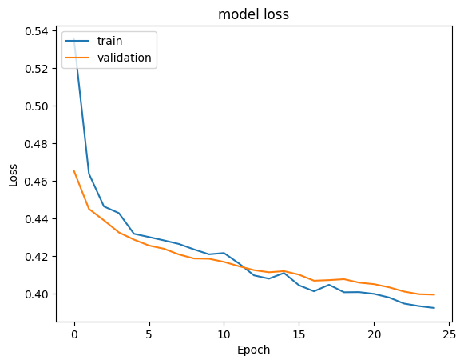

```python
#Plotting Train Loss vs Validation Loss
plt.plot(history_2.history['loss'])
plt.plot(history_2.history['val_loss'])
plt.title('model loss')
plt.ylabel('Loss')
plt.xlabel('Epoch')
plt.legend(['train', 'validation'], loc='upper left')
plt.show()
```

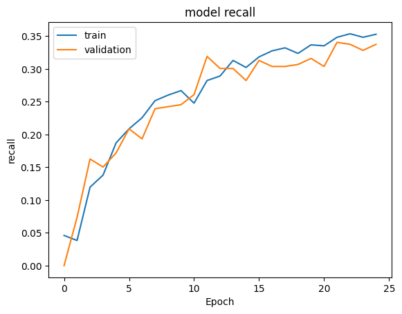

```python
#Plotting Train recall vs Validation recall
plt.plot(history_2.history['recall'])
plt.plot(history_2.history['val_recall'])
plt.title('model recall')
plt.ylabel('recall')
plt.xlabel('Epoch')
plt.legend(['train', 'validation'], loc='upper left')
plt.show()
```

```python
#Predicting the results using best as a threshold
y_train_pred = model_2.predict(X_train)
y_train_pred = (y_train_pred > 0.5)
y_train_pred
```

```
200/200 ━━━━━━━━━━━━━━━━━━━━ 1s 1ms/step
```

```
array([[False],
       [False],
       [False],
       ...,
       [False],
       [False],
       [False]])
```

```python
#Predicting the results using 0.5 as the threshold.
y_val_pred = model_2.predict(X_val)
y_val_pred = (y_val_pred > 0.5)
y_val_pred
```

```
50/50 ━━━━━━━━━━━━━━━━━━━━ 0s 1ms/step
```

```
array([[False],
       [False],
       [False],
       ...,
       [False],
       [False],
       [False]])
```

```python
model_name = "NN with Adam & Dropout"

train_metric_df.loc[model_name] = recall_score(y_train,y_train_pred)
valid_metric_df.loc[model_name] = recall_score(y_val,y_val_pred)
```

**Classification report**

```python
#classification report
cr=classification_report(y_train,y_train_pred)
print(cr)
```

```
              precision    recall  f1-score   support

           0       0.86      0.97      0.91      5096
           1       0.76      0.38      0.51      1304

    accuracy                           0.85      6400
   macro avg       0.81      0.67      0.71      6400
weighted avg       0.84      0.85      0.83      6400
```

```python
#classification report
cr = classification_report(y_val,y_val_pred)
print(cr)
```

```
              precision    recall  f1-score   support

           0       0.85      0.96      0.90      1274
           1       0.71      0.34      0.46       326

    accuracy                           0.84      1600
   macro avg       0.78      0.65      0.68      1600
weighted avg       0.82      0.84      0.81      1600
```

**Confusion matrix**

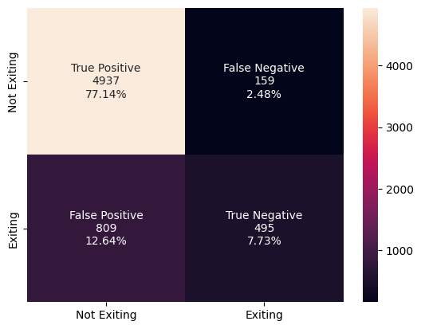

```python
# Displaying confusion matrix for the performance on Training dataset
cm=confusion_matrix(y_train, y_train_pred)
labels = ['True Positive','False Negative','False Positive','True Negative']
categories = [ 'Not Exiting','Exiting']
make_confusion_matrix(cm, group_names=labels, categories=categories)
```

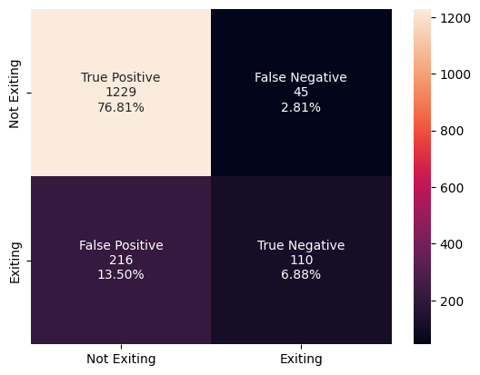

```python
# Displaying confusion matrix for the performance on Validation dataset
cm=confusion_matrix(y_val, y_val_pred)
labels = ['True Positive','False Negative','False Positive','True Negative']
categories = [ 'Not Exiting','Exiting']
make_confusion_matrix(cm, group_names=labels, categories=categories)
```

### Neural Network with Balanced Data (by applying SMOTE) and SGD Optimizer

**Let's try to apply SMOTE to balance this dataset and then again apply hyperparamter tuning accordingly.**

```python
print("Before UpSampling, counts of label 'Yes': {}".format(sum(y_train == 1)))
print("Before UpSampling, counts of label 'No': {} \n".format(sum(y_train == 0)))

sm  = SMOTE(random_state=42)

X_train_smote, y_train_smote= sm.fit_resample(X_train, y_train)

print("After UpSampling, counts of label 'Yes': {}".format(sum(y_train_smote == 1)))
print("After UpSampling, counts of label 'No': {} \n".format(sum(y_train_smote == 0)))

print('After UpSampling, the shape of train_X: {}'.format(X_train_smote.shape))
print('After UpSampling, the shape of train_y: {} \n'.format(y_train_smote.shape))
```

```
Before UpSampling, counts of label 'Yes': 1304
Before UpSampling, counts of label 'No': 5096

After UpSampling, counts of label 'Yes': 5096
After UpSampling, counts of label 'No': 5096

After UpSampling, the shape of train_X: (10192, 11)
After UpSampling, the shape of train_y: (10192,)
```

Let's build a model with the balanced dataset

```python
backend.clear_session()
#Fixing the seed for random number generators so that we can ensure we receive the same output everytime
np.random.seed(2)
random.seed(2)
tf.random.set_seed(2)
```

```python
#Initializing the model
model_3 = Sequential()

#Adding the input layer with 32 neurons and relu as activation function
model_3.add(Dense(32,activation='relu',input_dim = X_train_smote.shape[1]))

# Second hidden layer with 16 neurons and ReLU activation
model_3.add(Dense(16,activation='relu'))

# Third hidden layer with 8 neurons and ReLU activation
model_3.add(Dense(8,activation='relu'))

# Adding the output layer with one neuron and sigmoid activation
model_3.add(Dense(1, activation = 'sigmoid'))
```

```python
# Compiling the model with 'Binary cross entropy' as loss function and 'recall' as the metric
optimizer = tf.keras.optimizers.SGD(0.001)
model_3.compile(loss='binary_crossentropy', optimizer=optimizer,metrics=['recall'])

model_3.summary()
```

```
Model: "sequential"
```

```
┏━━━━━━━━━━━━━━━━━━━━━━━━━━━━━━━━━━━━━━┳━━━━━━━━━━━━━━━━━━━━━━━━━━━━━┳━━━━━━━━━━━━━━━━━┓
┃ Layer (type)                         ┃ Output Shape                ┃         Param # ┃
┡━━━━━━━━━━━━━━━━━━━━━━━━━━━━━━━━━━━━━━╇━━━━━━━━━━━━━━━━━━━━━━━━━━━━━╇━━━━━━━━━━━━━━━━━┩
│ dense (Dense)                        │ (None, 32)                  │             384 │
├──────────────────────────────────────┼─────────────────────────────┼─────────────────┤
│ dense_1 (Dense)                      │ (None, 16)                  │             528 │
├──────────────────────────────────────┼─────────────────────────────┼─────────────────┤
│ dense_2 (Dense)                      │ (None, 8)                   │             136 │
├──────────────────────────────────────┼─────────────────────────────┼─────────────────┤
│ dense_3 (Dense)                      │ (None, 1)                   │               9 │
└──────────────────────────────────────┴─────────────────────────────┴─────────────────┘
```

```
 Total params: 1,057 (4.13 KB)
```

```
 Trainable params: 1,057 (4.13 KB)
```

```
 Non-trainable params: 0 (0.00 B)
```

```python
# Fitting the model on training and validation with 25 epochs and batch_size 64.

history_3 = model_3.fit(
    X_train_smote,y_train_smote,
    batch_size=64,
    epochs=25,
    verbose=1,
    validation_data=(X_val,y_val)
)
```

```
160/160 ━━━━━━━━━━━━━━━━━━━━ 3s 12ms/step - loss: 0.7050 - recall: 0.9355 - val_loss: 0.7387 - val_recall: 0.9387
160/160 ━━━━━━━━━━━━━━━━━━━━ 0s 3ms/step - loss: 0.7029 - recall: 0.9304 - val_loss: 0.7329 - val_recall: 0.9264
160/160 ━━━━━━━━━━━━━━━━━━━━ 0s 3ms/step - loss: 0.7011 - recall: 0.9271 - val_loss: 0.7278 - val_recall: 0.9172
160/160 ━━━━━━━━━━━━━━━━━━━━ 1s 3ms/step - loss: 0.6995 - recall: 0.9237 - val_loss: 0.7232 - val_recall: 0.9172
160/160 ━━━━━━━━━━━━━━━━━━━━ 1s 3ms/step - loss: 0.6980 - recall: 0.9168 - val_loss: 0.7190 - val_recall: 0.9080
160/160 ━━━━━━━━━━━━━━━━━━━━ 1s 3ms/step - loss: 0.6967 - recall: 0.9026 - val_loss: 0.7150 - val_recall: 0.9049
160/160 ━━━━━━━━━━━━━━━━━━━━ 0s 2ms/step - loss: 0.6953 - recall: 0.8902 - val_loss: 0.7110 - val_recall: 0.8957
160/160 ━━━━━━━━━━━━━━━━━━━━ 1s 2ms/step - loss: 0.6940 - recall: 0.8713 - val_loss: 0.7068 - val_recall: 0.8712
160/160 ━━━━━━━━━━━━━━━━━━━━ 1s 2ms/step - loss: 0.6926 - recall: 0.8390 - val_loss: 0.7023 - val_recall: 0.8282
160/160 ━━━━━━━━━━━━━━━━━━━━ 1s 2ms/step - loss: 0.6909 - recall: 0.8031 - val_loss: 0.6973 - val_recall: 0.7945
160/160 ━━━━━━━━━━━━━━━━━━━━ 0s 2ms/step - loss: 0.6889 - recall: 0.7672 - val_loss: 0.6916 - val_recall: 0.7577
160/160 ━━━━━━━━━━━━━━━━━━━━ 1s 2ms/step - loss: 0.6866 - recall: 0.7315 - val_loss: 0.6857 - val_recall: 0.7239
160/160 ━━━━━━━━━━━━━━━━━━━━ 1s 2ms/step - loss: 0.6842 - recall: 0.6989 - val_loss: 0.6798 - val_recall: 0.6933
160/160 ━━━━━━━━━━━━━━━━━━━━ 0s 2ms/step - loss: 0.6818 - recall: 0.6723 - val_loss: 0.6742 - val_recall: 0.6748
160/160 ━━━━━━━━━━━━━━━━━━━━ 1s 2ms/step - loss: 0.6795 - recall: 0.6532 - val_loss: 0.6690 - val_recall: 0.6503
160/160 ━━━━━━━━━━━━━━━━━━━━ 1s 2ms/step - loss: 0.6773 - recall: 0.6417 - val_loss: 0.6643 - val_recall: 0.6442
160/160 ━━━━━━━━━━━━━━━━━━━━ 0s 2ms/step - loss: 0.6753 - recall: 0.6331 - val_loss: 0.6600 - val_recall: 0.6380
160/160 ━━━━━━━━━━━━━━━━━━━━ 0s 2ms/step - loss: 0.6733 - recall: 0.6324 - val_loss: 0.6560 - val_recall: 0.6288
160/160 ━━━━━━━━━━━━━━━━━━━━ 0s 2ms/step - loss: 0.6714 - recall: 0.6285 - val_loss: 0.6521 - val_recall: 0.6258
160/160 ━━━━━━━━━━━━━━━━━━━━ 0s 2ms/step - loss: 0.6695 - recall: 0.6258 - val_loss: 0.6485 - val_recall: 0.6227
160/160 ━━━━━━━━━━━━━━━━━━━━ 0s 2ms/step - loss: 0.6676 - recall: 0.6235 - val_loss: 0.6450 - val_recall: 0.6227
160/160 ━━━━━━━━━━━━━━━━━━━━ 0s 2ms/step - loss: 0.6657 - recall: 0.6241 - val_loss: 0.6418 - val_recall: 0.6227
160/160 ━━━━━━━━━━━━━━━━━━━━ 0s 2ms/step - loss: 0.6638 - recall: 0.6237 - val_loss: 0.6387 - val_recall: 0.6196
160/160 ━━━━━━━━━━━━━━━━━━━━ 1s 2ms/step - loss: 0.6618 - recall: 0.6219 - val_loss: 0.6356 - val_recall: 0.6196
160/160 ━━━━━━━━━━━━━━━━━━━━ 0s 2ms/step - loss: 0.6599 - recall: 0.6183 - val_loss: 0.6327 - val_recall: 0.6227
```

**Loss function**

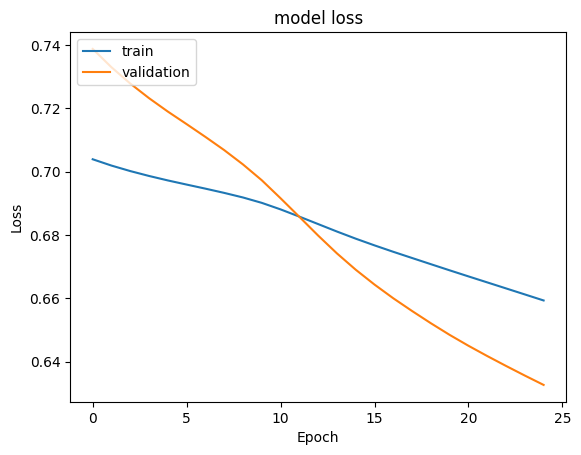

```python
#Plotting Train Loss vs Validation Loss
plt.plot(history_3.history['loss'])
plt.plot(history_3.history['val_loss'])
plt.title('model loss')
plt.ylabel('Loss')
plt.xlabel('Epoch')
plt.legend(['train', 'validation'], loc='upper left')
plt.show()
```

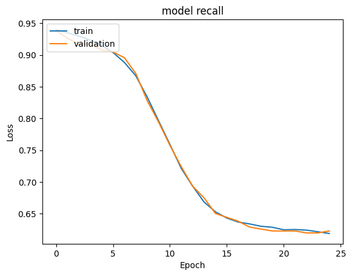

```python
#Plotting Train recall vs Validation recall
plt.plot(history_3.history['recall'])
plt.plot(history_3.history['val_recall'])
plt.title('model recall')
plt.ylabel('Loss')
plt.xlabel('Epoch')
plt.legend(['train', 'validation'], loc='upper left')
plt.show()
```

```python
y_train_pred = model_3.predict(X_train_smote)
#Predicting the results using 0.5 as the threshold
y_train_pred = (y_train_pred > 0.5)
y_train_pred
```

```
319/319 ━━━━━━━━━━━━━━━━━━━━ 1s 2ms/step
```

```
array([[ True],
       [False],
       [False],
       ...,
       [False],
       [ True],
       [False]])
```

```python
y_val_pred = model_3.predict(X_val)
#Predicting the results using 0.5 as the threshold
y_val_pred = (y_val_pred > 0.5)
y_val_pred
```

```
50/50 ━━━━━━━━━━━━━━━━━━━━ 0s 2ms/step
```

```
array([[ True],
       [False],
       [ True],
       ...,
       [ True],
       [ True],
       [ True]])
```

```python
model_name = "NN with SMOTE & SGD"

train_metric_df.loc[model_name] = recall_score(y_train_smote,y_train_pred)
valid_metric_df.loc[model_name] = recall_score(y_val,y_val_pred)
```

**Classification report**

```python
#classification report
cr=classification_report(y_train_smote,y_train_pred)
print(cr)
```

```
              precision    recall  f1-score   support

           0       0.63      0.64      0.63      5096
           1       0.63      0.62      0.63      5096

    accuracy                           0.63     10192
   macro avg       0.63      0.63      0.63     10192
weighted avg       0.63      0.63      0.63     10192
```

```python
#classification report
cr = classification_report(y_val,y_val_pred)
print(cr)
```

```
              precision    recall  f1-score   support

           0       0.87      0.63      0.73      1274
           1       0.30      0.62      0.41       326

    accuracy                           0.63      1600
   macro avg       0.59      0.63      0.57      1600
weighted avg       0.75      0.63      0.67      1600
```

**Confusion matrix**

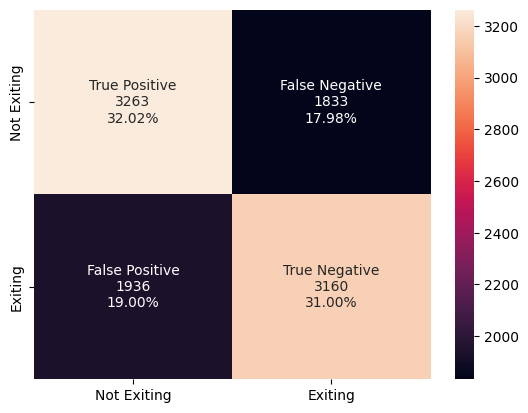

```python
# Displaying confusion matrix for the performance on Training dataset
cm=confusion_matrix(y_train_smote, y_train_pred)
labels = ['True Positive','False Negative','False Positive','True Negative']
categories = [ 'Not Exiting','Exiting']
make_confusion_matrix(cm, group_names=labels, categories=categories)
```

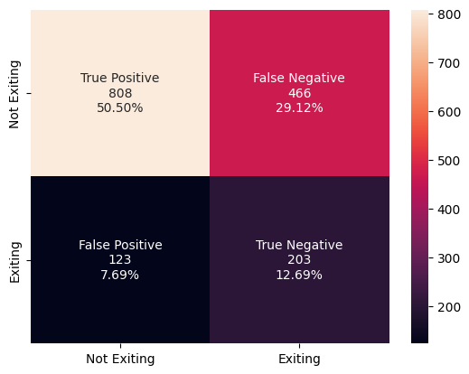

```python
# Displaying confusion matrix for the performance on Validation dataset
cm=confusion_matrix(y_val, y_val_pred)
labels = ['True Positive','False Negative','False Positive','True Negative']
categories = [ 'Not Exiting','Exiting']
make_confusion_matrix(cm, group_names=labels, categories=categories)
```

### Neural Network with Balanced Data (by applying SMOTE) and Adam Optimizer

```python
backend.clear_session()
#Fixing the seed for random number generators so that we can ensure we receive the same output everytime
np.random.seed(2)
random.seed(2)
tf.random.set_seed(2)
```

```python
#Initializing the model
model_4 = Sequential()

#Adding the input layer with 32 neurons and relu as activation function
model_4.add(Dense(32,activation='relu',input_dim = X_train_smote.shape[1]))

# Second hidden layer with 16 neurons and ReLU activation
model_4.add(Dense(16,activation='relu'))

# Third hidden layer with 8 neurons and ReLU activation
model_4.add(Dense(8,activation='relu'))

# Adding the output layer with one neuron and sigmoid activation
model_4.add(Dense(1, activation = 'sigmoid'))
```

```python
# Compiling the model with 'Binary cross entropy' as loss function and 'recall' as the metric
optimizer = tf.keras.optimizers.Adam()

model_4.compile(loss='binary_crossentropy', optimizer=optimizer,metrics=['recall'])

model_4.summary()
```

```
Model: "sequential"
```

```
┏━━━━━━━━━━━━━━━━━━━━━━━━━━━━━━━━━━━━━━┳━━━━━━━━━━━━━━━━━━━━━━━━━━━━━┳━━━━━━━━━━━━━━━━━┓
┃ Layer (type)                         ┃ Output Shape                ┃         Param # ┃
┡━━━━━━━━━━━━━━━━━━━━━━━━━━━━━━━━━━━━━━╇━━━━━━━━━━━━━━━━━━━━━━━━━━━━━╇━━━━━━━━━━━━━━━━━┩
│ dense (Dense)                        │ (None, 32)                  │             384 │
├──────────────────────────────────────┼─────────────────────────────┼─────────────────┤
│ dense_1 (Dense)                      │ (None, 16)                  │             528 │
├──────────────────────────────────────┼─────────────────────────────┼─────────────────┤
│ dense_2 (Dense)                      │ (None, 8)                   │             136 │
├──────────────────────────────────────┼─────────────────────────────┼─────────────────┤
│ dense_3 (Dense)                      │ (None, 1)                   │               9 │
└──────────────────────────────────────┴─────────────────────────────┴─────────────────┘
```

```
 Total params: 1,057 (4.13 KB)
```

```
 Trainable params: 1,057 (4.13 KB)
```

```
 Non-trainable params: 0 (0.00 B)
```

```python
# Fitting the model on training and validation with 25 epochs and batch_size 64.

history_4 = model_4.fit(
    X_train_smote,y_train_smote,
    batch_size=64,
    epochs=25,
    verbose=1,
    validation_data=(X_val,y_val)
)
```

```
160/160 ━━━━━━━━━━━━━━━━━━━━ 5s 9ms/step - loss: 0.6589 - recall: 0.7627 - val_loss: 0.5729 - val_recall: 0.6994
160/160 ━━━━━━━━━━━━━━━━━━━━ 0s 2ms/step - loss: 0.5597 - recall: 0.7268 - val_loss: 0.5638 - val_recall: 0.7117
160/160 ━━━━━━━━━━━━━━━━━━━━ 0s 2ms/step - loss: 0.5433 - recall: 0.7451 - val_loss: 0.5574 - val_recall: 0.7086
160/160 ━━━━━━━━━━━━━━━━━━━━ 1s 2ms/step - loss: 0.5246 - recall: 0.7556 - val_loss: 0.5455 - val_recall: 0.7362
160/160 ━━━━━━━━━━━━━━━━━━━━ 1s 2ms/step - loss: 0.4987 - recall: 0.7747 - val_loss: 0.5302 - val_recall: 0.7393
160/160 ━━━━━━━━━━━━━━━━━━━━ 0s 2ms/step - loss: 0.4746 - recall: 0.7871 - val_loss: 0.5185 - val_recall: 0.7546
160/160 ━━━━━━━━━━━━━━━━━━━━ 0s 2ms/step - loss: 0.4556 - recall: 0.7918 - val_loss: 0.5091 - val_recall: 0.7577
160/160 ━━━━━━━━━━━━━━━━━━━━ 1s 2ms/step - loss: 0.4418 - recall: 0.7991 - val_loss: 0.5083 - val_recall: 0.7607
160/160 ━━━━━━━━━━━━━━━━━━━━ 0s 2ms/step - loss: 0.4326 - recall: 0.7972 - val_loss: 0.5069 - val_recall: 0.7577
160/160 ━━━━━━━━━━━━━━━━━━━━ 0s 2ms/step - loss: 0.4251 - recall: 0.8006 - val_loss: 0.5078 - val_recall: 0.7546
160/160 ━━━━━━━━━━━━━━━━━━━━ 1s 2ms/step - loss: 0.4191 - recall: 0.8009 - val_loss: 0.5076 - val_recall: 0.7577
160/160 ━━━━━━━━━━━━━━━━━━━━ 1s 2ms/step - loss: 0.4138 - recall: 0.8057 - val_loss: 0.5068 - val_recall: 0.7669
160/160 ━━━━━━━━━━━━━━━━━━━━ 0s 2ms/step - loss: 0.4097 - recall: 0.8077 - val_loss: 0.5070 - val_recall: 0.7699
160/160 ━━━━━━━━━━━━━━━━━━━━ 0s 2ms/step - loss: 0.4063 - recall: 0.8114 - val_loss: 0.5083 - val_recall: 0.7699
160/160 ━━━━━━━━━━━━━━━━━━━━ 0s 2ms/step - loss: 0.4033 - recall: 0.8144 - val_loss: 0.5083 - val_recall: 0.7638
160/160 ━━━━━━━━━━━━━━━━━━━━ 1s 2ms/step - loss: 0.4008 - recall: 0.8152 - val_loss: 0.5088 - val_recall: 0.7546
160/160 ━━━━━━━━━━━━━━━━━━━━ 0s 2ms/step - loss: 0.3984 - recall: 0.8137 - val_loss: 0.5117 - val_recall: 0.7669
160/160 ━━━━━━━━━━━━━━━━━━━━ 0s 2ms/step - loss: 0.3964 - recall: 0.8140 - val_loss: 0.5125 - val_recall: 0.7638
160/160 ━━━━━━━━━━━━━━━━━━━━ 1s 3ms/step - loss: 0.3946 - recall: 0.8162 - val_loss: 0.5128 - val_recall: 0.7607
160/160 ━━━━━━━━━━━━━━━━━━━━ 1s 3ms/step - loss: 0.3925 - recall: 0.8171 - val_loss: 0.5130 - val_recall: 0.7577
160/160 ━━━━━━━━━━━━━━━━━━━━ 1s 3ms/step - loss: 0.3908 - recall: 0.8164 - val_loss: 0.5137 - val_recall: 0.7485
160/160 ━━━━━━━━━━━━━━━━━━━━ 1s 3ms/step - loss: 0.3891 - recall: 0.8191 - val_loss: 0.5147 - val_recall: 0.7515
160/160 ━━━━━━━━━━━━━━━━━━━━ 1s 3ms/step - loss: 0.3876 - recall: 0.8240 - val_loss: 0.5149 - val_recall: 0.7454
160/160 ━━━━━━━━━━━━━━━━━━━━ 1s 3ms/step - loss: 0.3862 - recall: 0.8244 - val_loss: 0.5152 - val_recall: 0.7393
160/160 ━━━━━━━━━━━━━━━━━━━━ 1s 2ms/step - loss: 0.3847 - recall: 0.8264 - val_loss: 0.5143 - val_recall: 0.7362
```

**Loss function**

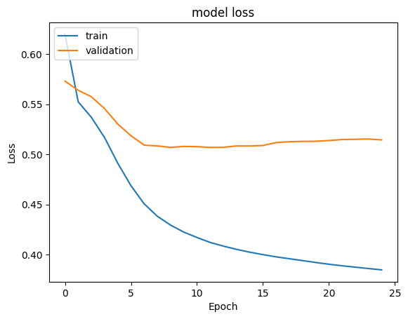

```python
#Plotting Train Loss vs Validation Loss
plt.plot(history_4.history['loss'])
plt.plot(history_4.history['val_loss'])
plt.title('model loss')
plt.ylabel('Loss')
plt.xlabel('Epoch')
plt.legend(['train', 'validation'], loc='upper left')
plt.show()
```

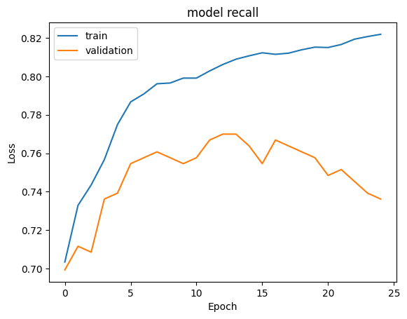

```python
#Plotting Train recall vs Validation recall
plt.plot(history_4.history['recall'])
plt.plot(history_4.history['val_recall'])
plt.title('model recall')
plt.ylabel('Loss')
plt.xlabel('Epoch')
plt.legend(['train', 'validation'], loc='upper left')
plt.show()
```

```python
y_train_pred = model_4.predict(X_train_smote)
#Predicting the results using 0.5 as the threshold
y_train_pred = (y_train_pred > 0.5)
y_train_pred
```

```
319/319 ━━━━━━━━━━━━━━━━━━━━ 1s 2ms/step
```

```
array([[ True],
       [False],
       [False],
       ...,
       [ True],
       [ True],
       [ True]])
```

```python
y_val_pred = model_4.predict(X_val)
#Predicting the results using 0.5 as the threshold
y_val_pred = (y_val_pred > 0.5)
y_val_pred
```

```
50/50 ━━━━━━━━━━━━━━━━━━━━ 0s 1ms/step
```

```
array([[ True],
       [False],
       [False],
       ...,
       [False],
       [ True],
       [ True]])
```

```python
model_name = "NN with SMOTE & Adam"

train_metric_df.loc[model_name] = recall_score(y_train_smote,y_train_pred)
valid_metric_df.loc[model_name] = recall_score(y_val,y_val_pred)
```

**Classification report**

```python
cr=classification_report(y_train_smote,y_train_pred)
print(cr)
```

```
              precision    recall  f1-score   support

           0       0.86      0.80      0.83      5096
           1       0.81      0.87      0.84      5096

    accuracy                           0.83     10192
   macro avg       0.83      0.83      0.83     10192
weighted avg       0.83      0.83      0.83     10192
```

```python
#classification report
cr = classification_report(y_val,y_val_pred)
print(cr)
```

```
              precision    recall  f1-score   support

           0       0.92      0.76      0.83      1274
           1       0.44      0.74      0.55       326

    accuracy                           0.76      1600
   macro avg       0.68      0.75      0.69      1600
weighted avg       0.82      0.76      0.78      1600
```

**Confusion matrix**

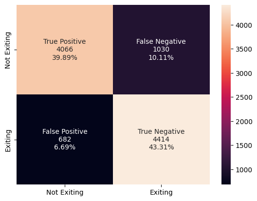

```python
# Displaying confusion matrix for the performance on Training dataset
cm=confusion_matrix(y_train_smote, y_train_pred)
labels = ['True Positive','False Negative','False Positive','True Negative']
categories = [ 'Not Exiting','Exiting']
make_confusion_matrix(cm, group_names=labels, categories=categories)
```

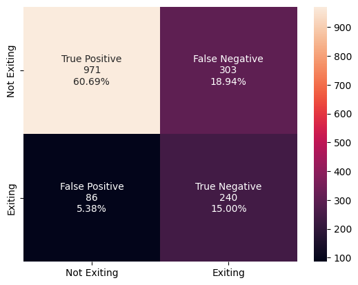

```python
# Displaying confusion matrix for the performance on Validation dataset
cm=confusion_matrix(y_val, y_val_pred)
labels = ['True Positive','False Negative','False Positive','True Negative']
categories = [ 'Not Exiting','Exiting']
make_confusion_matrix(cm, group_names=labels, categories=categories)
```

### Neural Network with Balanced Data (by applying SMOTE), Adam Optimizer, and Dropout

```python
backend.clear_session()
#Fixing the seed for random number generators so that we can ensure we receive the same output everytime
np.random.seed(2)
random.seed(2)
tf.random.set_seed(2)
```

```python
#Initializing the model
model_5 = Sequential()

#Adding the input layer with 32 neurons and relu as activation function
model_5.add(Dense(32,activation='relu',input_dim = X_train_smote.shape[1]))

# Adding dropout of 20%
model_5.add(Dropout(0.2))

# Second hidden layer with 16 neurons and ReLU activation
model_5.add(Dense(16,activation='relu'))

# Adding dropout of 10%
model_5.add(Dropout(0.1))

# Third hidden layer with 8 neurons and ReLU activation
model_5.add(Dense(8,activation='relu'))

# Adding the output layer with one neuron and sigmoid activation
model_5.add(Dense(1, activation = 'sigmoid'))
```

```python
# Compiling the model with 'Binary cross entropy' as loss function, 'recall' as the metric and Adam as the Optimizer
model_5.compile(loss='binary_crossentropy', optimizer='adam',metrics=['recall'])
```

```python
# Summary of the model
model_5.summary()
```

```
Model: "sequential"
```

```
┏━━━━━━━━━━━━━━━━━━━━━━━━━━━━━━━━━━━━━━┳━━━━━━━━━━━━━━━━━━━━━━━━━━━━━┳━━━━━━━━━━━━━━━━━┓
┃ Layer (type)                         ┃ Output Shape                ┃         Param # ┃
┡━━━━━━━━━━━━━━━━━━━━━━━━━━━━━━━━━━━━━━╇━━━━━━━━━━━━━━━━━━━━━━━━━━━━━╇━━━━━━━━━━━━━━━━━┩
│ dense (Dense)                        │ (None, 32)                  │             384 │
├──────────────────────────────────────┼─────────────────────────────┼─────────────────┤
│ dropout (Dropout)                    │ (None, 32)                  │               0 │
├──────────────────────────────────────┼─────────────────────────────┼─────────────────┤
│ dense_1 (Dense)                      │ (None, 16)                  │             528 │
├──────────────────────────────────────┼─────────────────────────────┼─────────────────┤
│ dropout_1 (Dropout)                  │ (None, 16)                  │               0 │
├──────────────────────────────────────┼─────────────────────────────┼─────────────────┤
│ dense_2 (Dense)                      │ (None, 8)                   │             136 │
├──────────────────────────────────────┼─────────────────────────────┼─────────────────┤
│ dense_3 (Dense)                      │ (None, 1)                   │               9 │
└──────────────────────────────────────┴─────────────────────────────┴─────────────────┘
```

```
 Total params: 1,057 (4.13 KB)
```

```
 Trainable params: 1,057 (4.13 KB)
```

```
 Non-trainable params: 0 (0.00 B)
```

```python
history_5 = model_5.fit(
    X_train_smote,y_train_smote,
    batch_size=64,
    epochs=25,
    verbose=1,
    validation_data = (X_val,y_val))
```

```
160/160 ━━━━━━━━━━━━━━━━━━━━ 7s 21ms/step - loss: 0.6516 - recall: 0.5739 - val_loss: 0.5600 - val_recall: 0.6411
160/160 ━━━━━━━━━━━━━━━━━━━━ 0s 2ms/step - loss: 0.5799 - recall: 0.7113 - val_loss: 0.5550 - val_recall: 0.6687
160/160 ━━━━━━━━━━━━━━━━━━━━ 1s 2ms/step - loss: 0.5633 - recall: 0.7154 - val_loss: 0.5494 - val_recall: 0.6840
160/160 ━━━━━━━━━━━━━━━━━━━━ 0s 2ms/step - loss: 0.5512 - recall: 0.7219 - val_loss: 0.5384 - val_recall: 0.6810
160/160 ━━━━━━━━━━━━━━━━━━━━ 0s 2ms/step - loss: 0.5395 - recall: 0.7261 - val_loss: 0.5340 - val_recall: 0.6687
160/160 ━━━━━━━━━━━━━━━━━━━━ 0s 2ms/step - loss: 0.5269 - recall: 0.7332 - val_loss: 0.5213 - val_recall: 0.6687
160/160 ━━━━━━━━━━━━━━━━━━━━ 0s 2ms/step - loss: 0.5233 - recall: 0.7417 - val_loss: 0.5193 - val_recall: 0.6840
160/160 ━━━━━━━━━━━━━━━━━━━━ 0s 2ms/step - loss: 0.5089 - recall: 0.7467 - val_loss: 0.5171 - val_recall: 0.6871
160/160 ━━━━━━━━━━━━━━━━━━━━ 1s 2ms/step - loss: 0.4981 - recall: 0.7485 - val_loss: 0.5105 - val_recall: 0.6933
160/160 ━━━━━━━━━━━━━━━━━━━━ 1s 2ms/step - loss: 0.4972 - recall: 0.7465 - val_loss: 0.5021 - val_recall: 0.6871
160/160 ━━━━━━━━━━━━━━━━━━━━ 1s 2ms/step - loss: 0.4854 - recall: 0.7612 - val_loss: 0.4989 - val_recall: 0.6963
160/160 ━━━━━━━━━━━━━━━━━━━━ 1s 2ms/step - loss: 0.4832 - recall: 0.7654 - val_loss: 0.4985 - val_recall: 0.7209
160/160 ━━━━━━━━━━━━━━━━━━━━ 1s 2ms/step - loss: 0.4869 - recall: 0.7623 - val_loss: 0.5000 - val_recall: 0.7209
160/160 ━━━━━━━━━━━━━━━━━━━━ 1s 2ms/step - loss: 0.4775 - recall: 0.7688 - val_loss: 0.4883 - val_recall: 0.7117
160/160 ━━━━━━━━━━━━━━━━━━━━ 0s 2ms/step - loss: 0.4680 - recall: 0.7616 - val_loss: 0.4850 - val_recall: 0.7209
160/160 ━━━━━━━━━━━━━━━━━━━━ 1s 2ms/step - loss: 0.4642 - recall: 0.7700 - val_loss: 0.4837 - val_recall: 0.7270
160/160 ━━━━━━━━━━━━━━━━━━━━ 0s 2ms/step - loss: 0.4596 - recall: 0.7709 - val_loss: 0.4768 - val_recall: 0.7239
160/160 ━━━━━━━━━━━━━━━━━━━━ 0s 2ms/step - loss: 0.4582 - recall: 0.7660 - val_loss: 0.4730 - val_recall: 0.7270
160/160 ━━━━━━━━━━━━━━━━━━━━ 1s 2ms/step - loss: 0.4531 - recall: 0.7878 - val_loss: 0.4690 - val_recall: 0.7178
160/160 ━━━━━━━━━━━━━━━━━━━━ 1s 2ms/step - loss: 0.4523 - recall: 0.7799 - val_loss: 0.4710 - val_recall: 0.7270
160/160 ━━━━━━━━━━━━━━━━━━━━ 0s 2ms/step - loss: 0.4479 - recall: 0.7764 - val_loss: 0.4669 - val_recall: 0.7301
160/160 ━━━━━━━━━━━━━━━━━━━━ 1s 3ms/step - loss: 0.4425 - recall: 0.7917 - val_loss: 0.4721 - val_recall: 0.7454
160/160 ━━━━━━━━━━━━━━━━━━━━ 1s 3ms/step - loss: 0.4399 - recall: 0.7904 - val_loss: 0.4532 - val_recall: 0.7209
160/160 ━━━━━━━━━━━━━━━━━━━━ 1s 3ms/step - loss: 0.4365 - recall: 0.7844 - val_loss: 0.4600 - val_recall: 0.7209
160/160 ━━━━━━━━━━━━━━━━━━━━ 1s 3ms/step - loss: 0.4327 - recall: 0.7933 - val_loss: 0.4563 - val_recall: 0.7301
```

**Loss function**

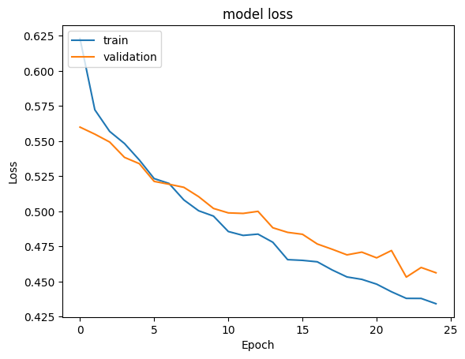

```python
#Plotting Train Loss vs Validation Loss
plt.plot(history_5.history['loss'])
plt.plot(history_5.history['val_loss'])
plt.title('model loss')
plt.ylabel('Loss')
plt.xlabel('Epoch')
plt.legend(['train', 'validation'], loc='upper left')
plt.show()
```

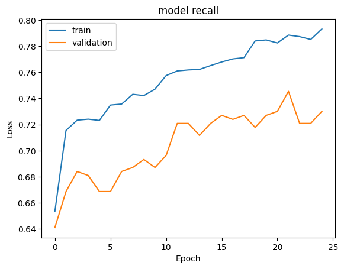

```python
#Plotting Train recall vs Validation recall
plt.plot(history_5.history['recall'])
plt.plot(history_5.history['val_recall'])
plt.title('model recall')
plt.ylabel('Loss')
plt.xlabel('Epoch')
plt.legend(['train', 'validation'], loc='upper left')
plt.show()
```

```python
y_train_pred = model_5.predict(X_train_smote)
#Predicting the results using 0.5 as the threshold
y_train_pred = (y_train_pred > 0.5)
y_train_pred
```

```
319/319 ━━━━━━━━━━━━━━━━━━━━ 1s 2ms/step
```

```
array([[ True],
       [False],
       [False],
       ...,
       [ True],
       [ True],
       [ True]])
```

```python
y_val_pred = model_5.predict(X_val)
#Predicting the results using 0.5 as the threshold
y_val_pred = (y_val_pred > 0.5)
y_val_pred
```

```
50/50 ━━━━━━━━━━━━━━━━━━━━ 0s 1ms/step
```

```
array([[False],
       [False],
       [False],
       ...,
       [False],
       [ True],
       [ True]])
```

```python
model_name = "NN with SMOTE,Adam & Dropout"

train_metric_df.loc[model_name] = recall_score(y_train_smote,y_train_pred)
valid_metric_df.loc[model_name] = recall_score(y_val,y_val_pred)
```

**Classification report**

```python
cr=classification_report(y_train_smote,y_train_pred)
print(cr)
```

```
              precision    recall  f1-score   support

           0       0.82      0.81      0.82      5096
           1       0.82      0.82      0.82      5096

    accuracy                           0.82     10192
   macro avg       0.82      0.82      0.82     10192
weighted avg       0.82      0.82      0.82     10192
```

```python
#classification report
cr = classification_report(y_val,y_val_pred)
print(cr)
```

```
              precision    recall  f1-score   support

           0       0.92      0.80      0.86      1274
           1       0.49      0.73      0.59       326

    accuracy                           0.79      1600
   macro avg       0.70      0.77      0.72      1600
weighted avg       0.83      0.79      0.80      1600
```

**Confusion matrix**

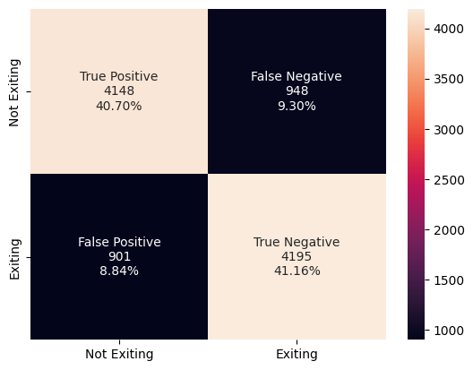

```python
# Displaying confusion matrix for the performance on Training dataset
cm=confusion_matrix(y_train_smote, y_train_pred)
labels = ['True Positive','False Negative','False Positive','True Negative']
categories = [ 'Not Exiting','Exiting']

make_confusion_matrix(cm, group_names=labels, categories=categories)
```

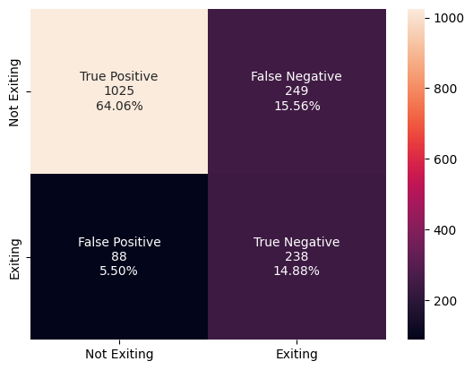

```python
# Displaying confusion matrix for the performance on Validation dataset
cm=confusion_matrix(y_val, y_val_pred)
labels = ['True Positive','False Negative','False Positive','True Negative']
categories = [ 'Not Exiting','Exiting']

make_confusion_matrix(cm, group_names=labels, categories=categories)
```

## Model Performance Comparison and Final Model Selection

```python
print("Training performance comparison")
train_metric_df
```

```
Training performance comparison
```

|  | recall |
| --- | --- |
| NN with SGD | 0.242331 |
| NN with Adam | 0.526840 |
| NN with Adam & Dropout | 0.379601 |
| NN with SMOTE & SGD | 0.620094 |
| NN with SMOTE & Adam | 0.866170 |
| NN with SMOTE,Adam & Dropout | 0.823195 |

```python
print("Validation set performance comparison")
valid_metric_df
```

```
Validation set performance comparison
```

|  | recall |
| --- | --- |
| NN with SGD | 0.199387 |
| NN with Adam | 0.420245 |
| NN with Adam & Dropout | 0.337423 |
| NN with SMOTE & SGD | 0.622699 |
| NN with SMOTE & Adam | 0.736196 |
| NN with SMOTE,Adam & Dropout | 0.730061 |

```python
train_metric_df - valid_metric_df
```

|  | recall |
| --- | --- |
| NN with SGD | 0.042945 |
| NN with Adam | 0.106595 |
| NN with Adam & Dropout | 0.042178 |
| NN with SMOTE & SGD | -0.002605 |
| NN with SMOTE & Adam | 0.129973 |
| NN with SMOTE,Adam & Dropout | 0.093133 |

## Observations on Models' Performance and Choosing the best model

**Summary:** The best model for this task is **"NN with SMOTE & Adam"**, as it achieves the highest recall on the validation set, which is the most important measure for evaluating the model's generalization to unseen data.

**Key Observations:**

**Trade-offs:**

- While "NN with SMOTE, Adam & Dropout" also performs well with a recall of 0.730061 on the validation set, it is slightly lower than "NN with SMOTE & Adam" (0.736196). If overfitting is a concern in other metrics, dropout could still be considered.

**Conclusion:**

- The **"NN with SMOTE & Adam"** is the best-performing model in terms of recall on the validation set, making it the ideal choice for identifying customers likely to churn.

```python
# Using model_4 i.e. NN with Balanced Data (by applying SMOTE) and Adam Optimizer to run on the test data.

y_test_pred = model_4.predict(X_test)
y_test_pred = (y_test_pred > 0.5)

print(y_test_pred)
```

```
63/63 ━━━━━━━━━━━━━━━━━━━━ 0s 1ms/step
[[False]
 [False]
 [False]
 ...
 [ True]
 [False]
 [False]]
```

```python
#lets print classification report

cr=classification_report(y_test,y_test_pred)

print(cr)
```

```
              precision    recall  f1-score   support

           0       0.93      0.78      0.85      1593
           1       0.47      0.77      0.58       407

    accuracy                           0.77      2000
   macro avg       0.70      0.77      0.71      2000
weighted avg       0.84      0.77      0.79      2000
```

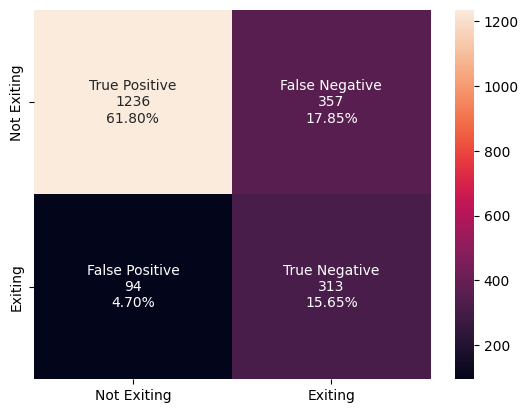

```python
# Displaying confusion matrix for the performance on Test dataset

cm=confusion_matrix(y_test, y_test_pred)

labels = ['True Positive','False Negative','False Positive','True Negative']

categories = [ 'Not Exiting','Exiting']

make_confusion_matrix(cm, group_names=labels, categories=categories)
```

## Observations:

The model performs well on the test data, with a recall of 0.77 for churners (Class 1). This is consistent with the validation results and confirms the model's ability to generalize. The slightly lower precision is an expected trade-off when optimizing for recall. This test performance supports the choice of "NN with SMOTE & Adam" as the best model.

**Recall for Class 1 (Churners/Existing):**

- Validation Recall (Best Model, "NN with SMOTE & Adam"): 0.736196
- Test Recall: 0.77

The recall on the test set (0.77) is slightly higher than the recall on the validation set (0.736). This indicates that the model generalizes well to unseen data and maintains its ability to correctly identify churners (Class 1) even when applied to the test set.

## Detailed Analysis of Test Results:

**1. Recall:**

- Class 0 (Non-Churners): 0.78
- Class 1 (Churners): 0.77

Recall for churners is high, indicating the model captures a substantial portion of actual churners, aligning with the business objective of reducing churn.

**2. Precision:**

- Class 0 (Non-Churners): 0.93
- Class 1 (Churners): 0.47

Precision for churners (Class 1) is relatively low, meaning there are a significant number of false positives. However, this is acceptable in a churn prediction problem, as the focus is on recall to avoid missing true churners.

**3. F1-Score:**

- Class 0 (Non-Churners): 0.85
- Class 1 (Churners): 0.58

The F1-score for churners is lower than for non-churners due to the trade-off between precision and recall. However, the recall-focused nature of the task makes this acceptable.

**4. Macro vs. Weighted Averages:**

## Actionable Insights and Business Recommendations

Here are actionable insights and business recommendations based on the churn prediction model results:

**1. Proactively Address High-Risk Customers**

- Insight: The model has a recall of 0.77 for churners, meaning it can identify 77% of customers at risk of leaving.
- Recommendation:
  - Use the model to flag high-risk customers early (Class 1 predictions).
  - Segment these customers by attributes like tenure, product usage, and complaints to tailor intervention strategies.
  - Assign relationship managers or customer success teams to reach out with personalized retention offers.

**2. Improve Customer Experience in Key Areas**

- Insight: Analyze churn-prone customers' behaviors and complaints to identify pain points (e.g., long service delays, hidden fees, or lack of certain features).
- Recommendation:
  - Conduct surveys or focus groups with churn-risk customers to understand dissatisfaction drivers.
  - Address frequent issues by offering fee waivers, improving support response times, or introducing new product features.
  - Invest in loyalty programs to reward long-standing customers.

**3. Address Class Imbalance in Retention Efforts**

- Insight: Precision for churners (Class 1) is 0.47, meaning some non-churners might be misclassified.
- Recommendation:
  - Avoid overloading low-risk customers with unnecessary offers by refining thresholds for churn prediction.
  - Use secondary validation steps (e.g., customer surveys or call follow-ups) before launching costly retention programs.

**4. Optimize Customer Support and Onboarding Processes**

- Insight: Early-stage customers might churn due to poor onboarding experiences.
- Recommendation:
  - Revamp onboarding to ensure customers are quickly educated about products and services.
  - Provide proactive customer support for new customers during their first 6 months, as early churners are typically more common.

**5. Monitor and Iterate**

- Insight: The model's performance depends on continuously updated data.
- Recommendation:
  - Regularly update the model with fresh data to account for changing customer behaviors and market trends.
  - Track metrics like recall and false positives over time to evaluate and improve the model's effectiveness.

**6. Cross-Sell and Upsell to Improve Retention**

- Insight: Customers with multiple products are less likely to churn.
- Recommendation:
  - Encourage at-risk customers to adopt additional products or services through tailored promotions.
  - Offer bundled deals or incentives to make switching providers less attractive.

**7. Invest in Predictive Maintenance**

- Insight: High recall suggests the ability to predict churn, but false positives could lead to resource inefficiency.
- Recommendation:
  - Use the model to predict and act before dissatisfaction escalates, reducing churn without excessive costs.
  - Automate early warning systems to flag churn risk based on declining engagement or transaction volume.

**Business Value:**

- Increased Retention: Even a small reduction in churn can significantly increase lifetime customer value and revenue.
- Better Resource Allocation: Focus on high-risk customers while avoiding unnecessary retention efforts for low-risk ones.
- Improved Customer Satisfaction: Proactive efforts and personalized engagement can strengthen loyalty and trust.